# SAR model

Masatoshi Katabuchi

August 19, 2019

- Nested dataframe `n_d3` and dataframe `sar_dat` contain SAR corrected values (`transformed_metric`) for single trait metrics (CWM, MPD, MNND, SES.MPD, SES.MNND and range)
- Similalry, `fd_nd3` and `sar_dat_m` contain SAR corrected values for multivarate metrics (FR, MPD and MNND)

# 1 Data preparation

## 1.1 MPD,SES.MPD, MNND (MNTD), SES.MNND and Range for each trait

- First, I calucated FD metrics.
- We can change the distance matrix from `gower` to `euclidean`.

```r
library(cluster)
library(picante)
library(FD)

load("./data/SE_dat.rda")

site_name <- paste(rep(0:11, each = 32), rep(7:38, 12), sep = "_")
trait_name <- colnames(trait)
site_dat <- tibble(site = site_name)
samp_vec <- c("d1", "d2", "d3")

#trait_raw <- trait
#trait <- scale(trait_raw) %>% as.data.frame


#range
com_range <- function(samp, trait, traitname)
{
  N <- dim(samp)[1]
  X <- paste(traitname)
  comRange <- numeric(N)
  max <- numeric(N)
  min <- numeric(N)

  for (i in 1:N){
    sppInSample <- names(samp[i,samp[i,] > 0] )
    if(length(sppInSample) > 1) {
      sppInTrait <- trait[sppInSample, ]
      max[i] <- max(sppInTrait[, X], na.rm = TRUE)
      min[i] <- min(sppInTrait[, X], na.rm = TRUE)
      comRange[i] <- max[i] - min[i]
    }
    else {
      comRange[i] <- NA
    }
  }
  comRange
}



library(snowfall)
sfInit(parallel = T, cpu = parallel::detectCores())
sfLibrary(cluster)
```

```
## Library cluster loaded.
```

```r
sfLibrary(picante)
```

```
## Library picante loaded.
```

```r
par_func <- function(x, metric, samp, t_dis) {
  if (metric == "mpd") {
    tmp1 <- mpd(samp, t_dis, abundance.weighte = T)
  } else if (metric == "mntd"){
    tmp1 <- mntd(samp, t_dis, abundance.weighte = T)
  } else if (metric == "range"){
    tmp1 <- com_range(samp, trait, trait_name[i])
  } else if (metric == "ses.mpd") {
    tmp1 <- ses.mpd(samp,
                    t_dis,
                    null.model = "taxa.labels",
                    abundance.weighted = T,
                    runs = 49)$mpd.obs.z
  } else if (metric == "ses.mntd"){
    tmp1 <- ses.mntd(samp,
                     t_dis,
                     null.model = "taxa.labels",
                     abundance.weighted = T,
                     runs = 49)$mntd.obs.z
  }
  tmp1
}

fd_func <- function(x, metric){
  year_tmp <- c(1976, 1996, 2006)
  samp <- get(samp_vec[x])
  trait_edit <- trait[colnames(samp), ]
  t_dis <- daisy(trait_edit[, x] %>%
                 as.matrix,
               metric = "gower") %>% as.matrix
  colnames(t_dis) <- rownames(t_dis) <- rownames(trait_edit)
  sfExport("t_dis", "metric", "samp")
  #mpd_mat <- sapply(1:8, function(x)par_func(x, metric, samp, t_dis))
  mpd_mat <- sfSapply(1:8, function(x)par_func(x, metric, samp, t_dis))
  colnames(mpd_mat) <- colnames(trait_edit)
  mpd_mat %>%
    as_tibble %>%
    mutate(site = rownames(samp)) %>%
    full_join(., site_dat, by = "site") %>%
    mutate(metric_name = metric) %>%
    mutate(time = year_tmp[x])
}

metric_name <- c("mpd", "mntd", "range", "ses.mpd", "ses.mntd")

sfExportAll()
fd_list <- NULL
before <- proc.time()
for (i in 1:length(metric_name)) {
  fd_list <- append(fd_list,
                    lapply(1:3, function(x)fd_func(x, metric_name[i])))
}
after <- proc.time()
after - before
```

```
##    user  system elapsed
##   1.334   0.240  30.343
```

```r
fd_dat0 <- NULL
for (i in 1:length(fd_list)) fd_dat0 <- rbind(fd_dat0, fd_list[[i]])

fd_dat <- fd_dat0 %>%
  mutate(gx = strsplit(site, "_") %>% sapply("[", 1) %>% as.numeric) %>%
  mutate(gy = strsplit(site, "_") %>% sapply("[", 2) %>% as.numeric) %>%
  mutate(year_site = paste(time, site, sep = "_"))
```

## 1.2 FR, MPD and MNND (MNTD) for PC1 and PC2

```r
list_fun2 <- function(){
  year_tmp <- c(1976, 1996, 2006)
  fd_list <- list()
  for (j in 1:3) {
    samp <- get(samp_vec[j])
    trait_edit <- trait[colnames(samp), c("Comp.1", "Comp.2")]
    t_dis <- daisy(trait_edit,
                   metric = "gower") %>% as.matrix
    colnames(t_dis) <- rownames(t_dis) <- rownames(trait_edit)
    mpd_vec <- mpd(samp, t_dis, abundance.weighted = T)
    mntd_vec <- mntd(samp, t_dis, abundance.weighted = T)
    #tmp1 <- dbFD(t_dis, samp)
    #w <- apply(samp, 2, sum)
    tmp1 <- dbFD(trait_edit, samp, w.abun = T)
    FR_vec <- tmp1$FRic
    fd_list[[j]] <- tibble(mpd_PCA = mpd_vec,
                           mntd_PCA = mntd_vec,
                           FR_PCA = FR_vec,
                           site = rownames(samp)) %>%
      full_join(., site_dat, by = "site") %>%
      mutate(time = year_tmp[j])
  }
  fd_list
}

fd_list <- list_fun2()
```

[output not shown]

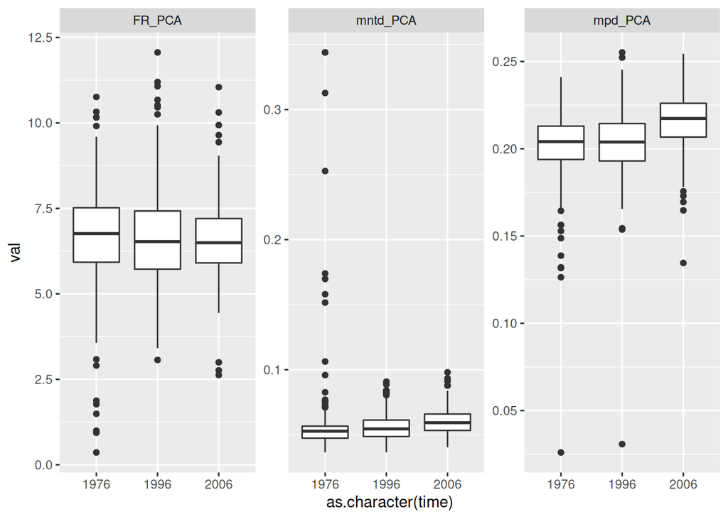

```r
fd_m_dat <- bind_rows(fd_list[[1]],
                     fd_list[[2]],
                     fd_list[[3]]) %>%
  mutate(gx = strsplit(site, "_") %>% sapply("[", 1) %>% as.numeric) %>%
  mutate(gy = strsplit(site, "_") %>% sapply("[", 2) %>% as.numeric) %>%
  mutate(year_site = paste(time, site, sep = "_")) %>%
  arrange(year_site) %>%
  mutate(temp2 = rep(1:(nrow(.)/3), 3) %>% as.character)

fd_m_dat %>%
  gather(fd_name, val, 1:3) %>%
  ggplot(., aes(x = as.character(time), y = val)) +
  facet_wrap(~ fd_name, scale = "free") +
  geom_boxplot()
```

```r
fd_nd <- fd_m_dat %>%
  gather(fd_name, val, 1:3) %>%
  group_by(fd_name, time) %>%
  nest()
```

## 1.3 Merge FD (single traits) and CWM data

- Three quadrats are missing

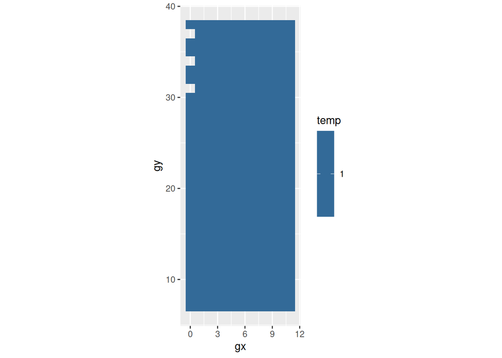

```r
d1 <- trait_com2 %>%
  filter(time == 1976)

ggplot(d1, aes(x = gx, y = gy, fill = temp)) +
  geom_raster() +
  coord_fixed()
```

- We need to add rows for those missing data

```r
trait_com3 <- trait_com2 %>%
  mutate(metric_name = "CWM") %>%
  dplyr::select(1:8,
                site,
                metric_name,
                time,
                gx,
                gy,
                year_site)

gy_tmp <- c(31, 34, 37)
year_tmp <- c(1976, 1996, 2006)
na_dat <- NULL

for (i in 1:3) {
  for (j in 1:3) {
    tmp <- trait_com3 %>%
      slice(1)
    tmp[1:8] <- NA
    tmp[1:8] <- as.numeric(tmp[1:8])
    tmp$gx <- 0
    tmp$gy <- gy_tmp[i]
    tmp$site <- paste(tmp$gx, tmp$gy, sep = "_")
    tmp$time <- year_tmp[j]
    tmp$year_site <- paste(tmp$time, tmp$site, sep = "_")
    na_dat <- rbind(na_dat, tmp)
  }
}

trait_com4 <- bind_rows(na_dat, trait_com3) %>%
  bind_rows(., fd_dat) %>%
  arrange(year_site) %>%
  arrange(metric_name) %>%
  mutate(temp2 = rep(1:(nrow(.)/18), 18) %>% as.character)

n_d <- trait_com4 %>%
  gather(trait_name, val, 1:8) %>%
  group_by(trait_name, metric_name, time) %>%
  nest()
```

## 1.4 SAR model

```r
library(spdep)
library(spatialreg)


d_nb <- cell2nb(12, 32, type = "queen")
d_W <- nb2listw(d_nb, zero.policy = T, style = "W")

sar_fun <- function(data) {
  metric <- data$val
  res <- spautolm(metric ~ 1, listw = d_W, na.action = na.omit)
  #res$fit$fitted.values
  res2 <- res$fit$fitted.values
  res_data <- tibble(temp2 = names(res2), transformed_metric = res2)
  res_data
}
```

We apply the function to the nested data.

```r
# single trait FD
before <- proc.time()
n_d2 <- n_d %>%
  mutate(sar_val = map(data, sar_fun))
after <- proc.time()
after - before
```

```
##    user  system elapsed
##  93.628   0.326  60.508
```

```r
# multivariate FD
before <- proc.time()
fd_nd2 <- fd_nd %>%
  mutate(sar_val = map(data, sar_fun))
after <- proc.time()
after - before
```

```
##    user  system elapsed
##   6.822   0.009   4.081
```

```r
mer_fun <- function(data, sar_val){
  full_join(data, sar_val, by = "temp2")
}


# single trait FD
n_d3 <- n_d2 %>%
  mutate(data2 = map2(data, sar_val, mer_fun)) %>%
  dplyr::select(trait_name, metric_name, time, data2)

# multivariate FD
fd_nd3 <- fd_nd2 %>%
  mutate(data2 = map2(data, sar_val, mer_fun)) %>%
  dplyr::select(fd_name, time, data2)
```

Now we have SAR transformed values for each trait, each trait metric and each census.

```r
sar_dat <- n_d3 %>%
  unnest()

sar_dat_m <- fd_nd3 %>%
  unnest()

n_d3
```

```
## # A tibble: 144 x 4
##    trait_name metric_name  time data2
##    <chr>      <chr>       <dbl> <list>
##  1 SEED       CWM          1976 <tibble [384 × 7]>
##  2 SEED       CWM          1996 <tibble [384 × 7]>
##  3 SEED       CWM          2006 <tibble [384 × 7]>
##  4 SEED       mntd         1976 <tibble [384 × 7]>
##  5 SEED       mntd         1996 <tibble [384 × 7]>
##  6 SEED       mntd         2006 <tibble [384 × 7]>
##  7 SEED       mpd          1976 <tibble [384 × 7]>
##  8 SEED       mpd          1996 <tibble [384 × 7]>
##  9 SEED       mpd          2006 <tibble [384 × 7]>
## 10 SEED       range        1976 <tibble [384 × 7]>
## # … with 134 more rows
```

- `sar_dat`: dataframe for single trait metrics
  - `trait_name`: Trait name
  - `metric_name`: CWM, mpd, mntd, ses.mpd, ses.mntd and range
  - `val`: Orignial values
  - `transformed_metric`: SAR transformed values
- `sar_dat_m`: dataframe for multivaraite trait metrics
  - `trait_name`: Trait name
  - `metric_name`: FR, mpd and mntd
  - `val`: Orignial values
  - `transformed_metric`: SAR transformed values

Just showing the first 200 rows of `sar_dat`.

```r
sar_dat %>%
  mutate(val = round(val, 3),
        transformed_metric = round(transformed_metric, 3)) %>%
  head(200) %>%
  DT::datatable()
```

|  | trait_name | metric_name | time | site | gx | gy | year_site | temp2 | val | transformed_metric |
| --- | --- | --- | --- | --- | --- | --- | --- | --- | --- | --- |
| 1 | SEED | CWM | 1976 | 0_10 | 0 | 10 | 1976_0_10 | 1 | 1.803 | 1.816 |
| 2 | SEED | CWM | 1976 | 0_11 | 0 | 11 | 1976_0_11 | 2 | 1.837 | 1.833 |
| 3 | SEED | CWM | 1976 | 0_12 | 0 | 12 | 1976_0_12 | 3 | 1.923 | 1.839 |
| 4 | SEED | CWM | 1976 | 0_13 | 0 | 13 | 1976_0_13 | 4 | 1.977 | 1.831 |
| 5 | SEED | CWM | 1976 | 0_14 | 0 | 14 | 1976_0_14 | 5 | 1.838 | 1.822 |
| 6 | SEED | CWM | 1976 | 0_15 | 0 | 15 | 1976_0_15 | 6 | 1.96 | 1.811 |
| 7 | SEED | CWM | 1976 | 0_16 | 0 | 16 | 1976_0_16 | 7 | 1.84 | 1.821 |
| 8 | SEED | CWM | 1976 | 0_17 | 0 | 17 | 1976_0_17 | 8 | 1.9 | 1.815 |
| 9 | SEED | CWM | 1976 | 0_18 | 0 | 18 | 1976_0_18 | 9 | 1.745 | 1.802 |
| 10 | SEED | CWM | 1976 | 0_19 | 0 | 19 | 1976_0_19 | 10 | 1.881 | 1.801 |

[output cut: 190 more lines]

CWM SEED (without SAR)

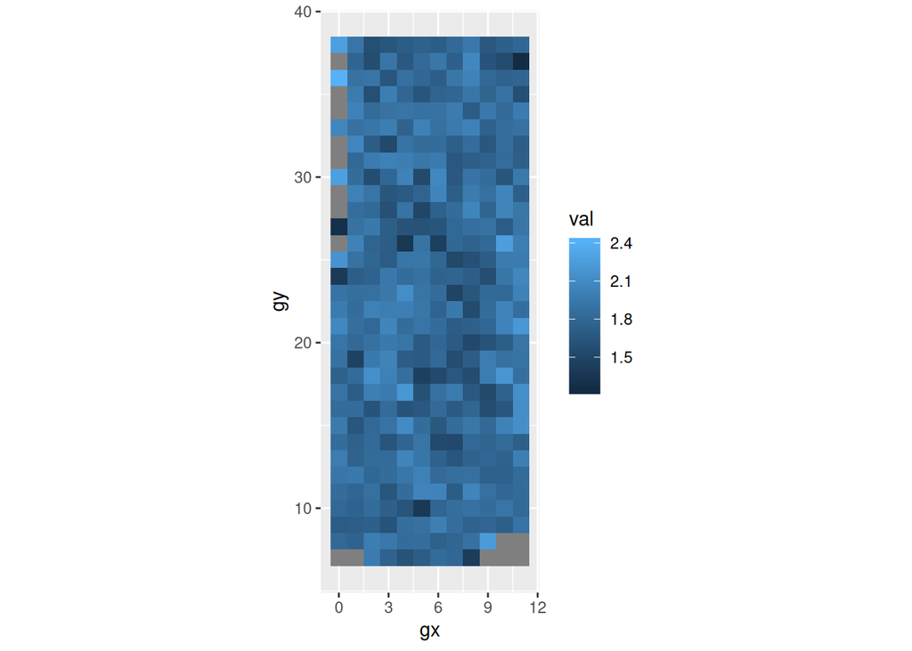

```r
moge <- n_d3$data2[[1]]

ggplot(moge, aes(x = gx, y = gy, fill = val)) +
  geom_raster() +
  coord_fixed()
```

CWM SEED (SAR corrected)

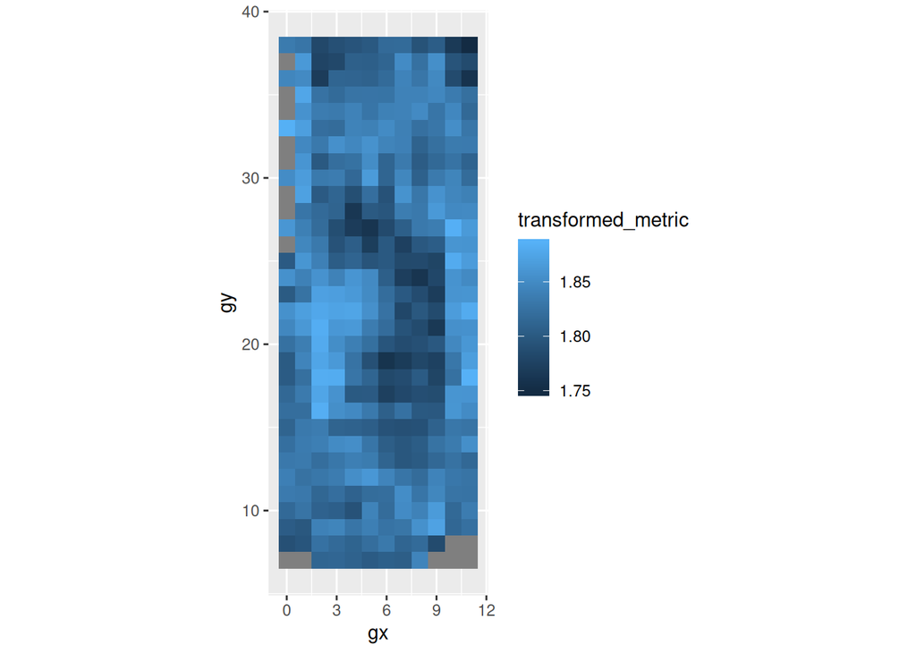

```r
ggplot(moge, aes(x = gx, y = gy, fill = transformed_metric)) +
  geom_raster() +
  coord_fixed()
```

```r
save.image("./data/SAR_dat.rda")
```

# 2 Analysis